# Word Psychic

Melissa Tan  
April 2015

A word prediction app ([link](http://melissatan.shinyapps.io/word_psychic))

Made for Coursera data science specialization, Swiftkey capstone project.

### App description

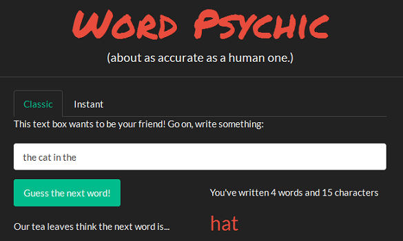

The app lets the user type in a phrase. It predicts the most likely next word, based on frequently occurring phrases (n-grams).

**How it was made:**

I used 2-grams to 5-grams, drawn from ~12,000 lines of English from blogs, news articles and Twitter.

I cleaned the text to remove things like punctuation (except apostrophes). I also replaced all words that appeared only once with a placeholder, `unk`. These could be typos or words like “zzzzzz”.

### App function and instructions

**How the app works:**

1. User inputs a phrase (as many words as she wants)
2. App looks at the last 1-4 words in phrase
3. App checks the database for phrases that match
4. App gathers all the possible predicted words and displays the most likely one

**How to use the app:**

- Classic mode: Type into the text field, and click the button to see the predicted next word.
- Instant mode: Type into the text field, and wait. The app automatically displays the predicted next word.

### Behind the scenes: Algorithm used

The algorithm used is *Stupid Backoff*, described in Brants et al, 2007 ([link, see section 4](http://www.aclweb.org/anthology/D07-1090.pdf)). I chose this because it is inexpensive and loads fast, while performing nearly as well as Kneser-Ney smoothing – which is quite good.

The algo gives each candidate word a score, based on its n-gram frequency. Mathematically, let \( Score = \begin{cases} \frac {freq(w_i)_{n=k+1}} {freq(w_{i-k}^{i-1})_{n=k+1}} & \text{if } freq(w_{i-k}^i)_{n=k+1} > 0 \\ \alpha \frac {freq(w_i)_{n=k}} {freq(w_{i-(k-1)}^{i-1})_{n=k}} & \text{otherwise} \end{cases} \)

Hypothetical example: user types `cat in the`. One possible next word is `hat`. We look in the 4-gram first (`n = 4`). The score for `hat` is given by: \[ Score(\text{"hat"}) = \begin{cases} \frac {freq(\text{"hat"})_{n=4}} {freq(\text{"cat in the"})_{n=4}} & \text{if } freq(\text{"cat in the hat"})_{n=4} > 0 \\ \alpha \frac {freq(\text{"hat"})_{n=3}} {freq(\text{"in the"})_{n=3}} & \text{otherwise} \end{cases} \]

Note that the score depends on the *relative* frequency, which is also the Maximum Likelihood Estimate (MLE), in this case.

### Algorithm walk-through example

User input: `"The CAT, in the ?"`. What the algo does is:

- Cleans up and standardizes the input, turning it into: `"the cat in the"`.
- Check 5-gram data for all occurrences of `the cat in the *`, where * denotes any word. Similarly, check 4-gram data for `cat in the *`, check 3-gram data for `in the *`, check 2-gram data for `the *`. Make a list of all the `*` candidate words.
- For each word, find maximum likelihood estimate (MLE) in the corresponding n-gram, compute overall score (set \( \alpha \) = `0.4`), and produce a score table. Below are the first 3 rows of an example score table, which show that `hat` followed 100% of the `the cat in the` instances in the 5-gram.

| nextword | n5.MLE | n4.MLE | n3.MLE | n2.MLE | score |
| --- | --- | --- | --- | --- | --- |
| hat | 100 | 100 | 0 | 0 | 100.0 |
| unk | 0 | 0 | 3 | 4 | 0.5 |
| first | 0 | 0 | 2 | 1 | 0.3 |

- Remove any `unk` rows. (since `unk` was a placeholder for words that only appeared once)
- Output the word with the top score. If there are multiple words with the same top score, randomly pick one. If user turns on *safe mode* and the output word is a profanity, censor the output.